# SITCOM-1120: Brake analysis

# Dates and time of the brake test

#### E-stop on 2023-11-23

1. Az: 2023-11-23T00:40:35
2. El: 2023-11-23T01:37:20
- BLOCK-142 : https://jira.lsstcorp.org/browse/BLOCK-142

#### ComCam onsky campaign using GIS door interlock

1. 1% speed set
   - Az: 2024-11-06 09:20
   - El: 2024-11-06 09:32
2. 2% speed set
   - Az: 2024-11-08T04:41:43.430Z
   - El: 2024-11-08T05:28:23Z
3. 5% speed set
   - Az: 2024-11-09 09:44 to 09:46
   - El: 2024-11-09 10:20 to 10:21
4. 10% speed set
   - Az: 2024-11-21 10:40 - 10:42
   - El: 2024-11-21 11:06 - 11:07
5. 20% speed set
   - Az: 2024-11-29 20:04
   - El: 2024-11-29 20:08
6. 40% speed set
   - Az: 2024-12-08 09:06:11
   - El: 2024-12-08 09:02:22
- Az brake test : BLOCK-T231
- El brake test : BLOCK-T240

# Cases

## 1-1: Az brake test on 2023-11-23

- time_start = "2023-11-23T00:40:35"
- time_ends = "2023-11-23T00:40:40"
- Event happened at: 2023-11-23T00:40:36.120481

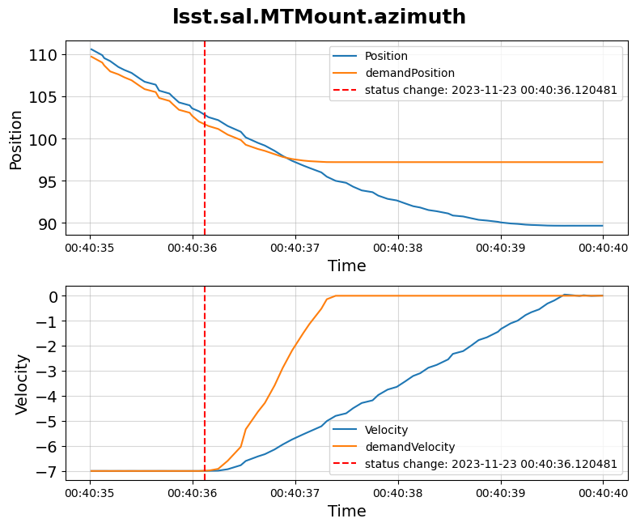

```python
##################################################
time_start = "2023-11-23T00:40:35"
time_ends = "2023-11-23T00:40:40"
##################################################
start, end = format_time(time_start, time_ends)
df_az = call_az_data_range(start, end)
##################################################
plot_az_woacc(df_az, event1)
```

#### stopping distance = 12.87 deg

## 1-2: El brake test on 2023-11-23

- time_start = "2023-11-23T01:37:20"
- time_ends = "2023-11-23T01:37:40"
- Event happened at: 2023-11-23T01:37:23.124712

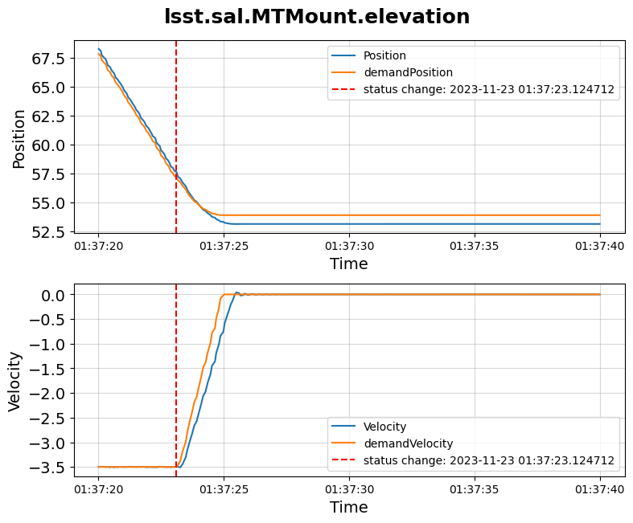

```python
##################################################
time_start = "2023-11-23T01:37:20"
time_ends = "2023-11-23T01:37:40"
##################################################
start, end = format_time(time_start, time_ends)
df_el = call_el_data_range(start, end)
##################################################
plot_el_woacc(df_el, event2)
##################################################
```

#### Stopping distance = 4.46 deg

## Case 2-1. ComCam onsky: 1% speed Az Brake Test

- time_start = "2024-11-06T09:21:31"
- time_ends = "2024-11-06T09:21:35"
- Event happened at: 2024-11-06T09:21:31.580298

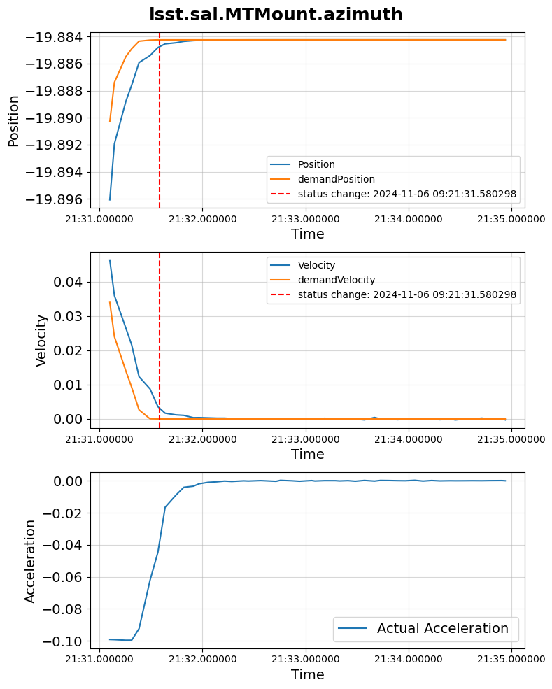

```python
plot_az(df_az, event1)
```

#### Stopping distance = -0.00057 deg

## Case 2-2. ComCam onsky: 1% speed El Brake Test

- time_start = "2024-11-06T09:34:43"
- time_ends = "2024-11-06T09:34:50"
- Event happened at: 2024-11-06T09:34:45.864699

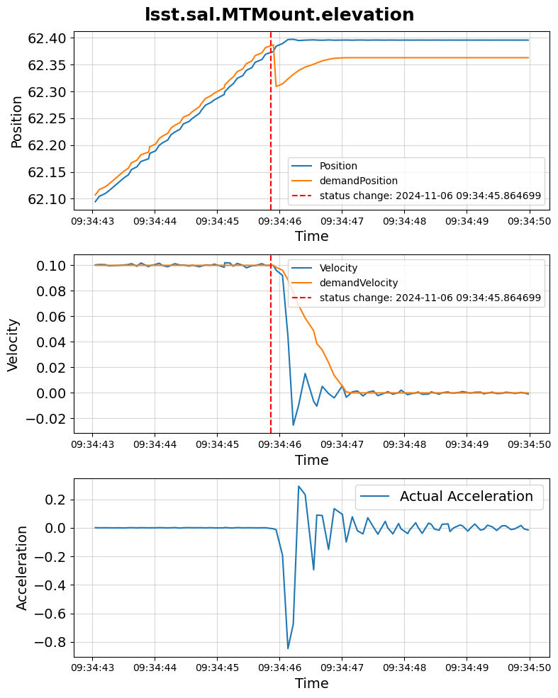

```python
##################################################
time_start = "2024-11-06T09:34:43"
time_ends = "2024-11-06T09:34:50"
##################################################
start, end = format_time(time_start, time_ends)
df_el = call_el_data_range(start, end)
##################################################
plot_el(df_el, event2)
##################################################
```

## Case 2-3. ComCam onsky: 2% speed Az Brake Test

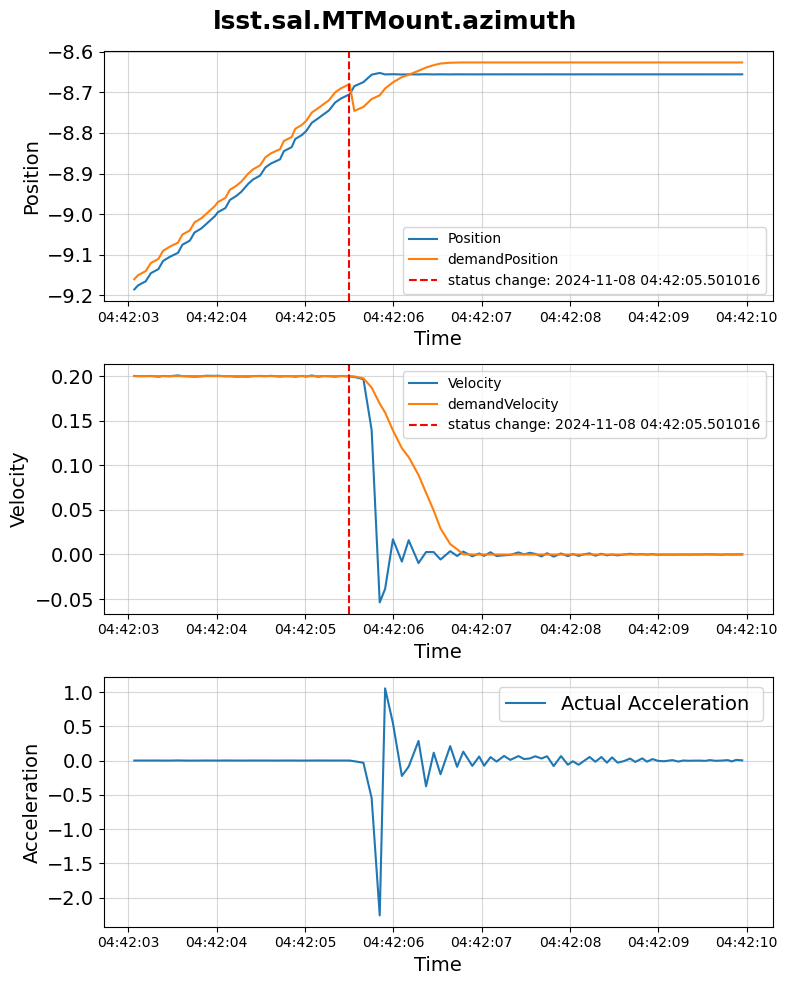

```python
##################################################
time_start = "2024-11-08T04:42:03"
time_ends = "2024-11-08T04:42:10"
##################################################
start, end = format_time(time_start, time_ends)
df_az = call_az_data_range(start, end)
##################################################
plot_az(df_az, event1)
```

#### Stopping distance = -0.049 deg

## Case 2-4. ComCam onsky: 2% speed El Brake Test

- time_start = "2024-11-08T05:27:31"
- time_ends = "2024-11-08T05:27:50"
- Event happened at: 2024-11-08T05:27:37.546319

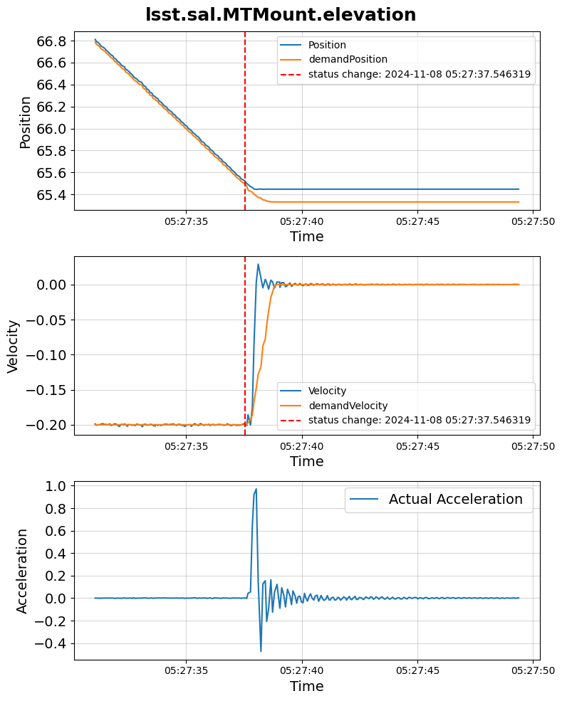

```python
##################################################
time_start = "2024-11-08T05:27:31"
time_ends = "2024-11-08T05:27:50"
##################################################
start, end = format_time(time_start, time_ends)
df_el = call_el_data_range(start, end)
##################################################
plot_el(df_el, event2)
##################################################
```

#### Stopping distance = 0.073 deg

## Case 2-5. ComCam onsky: 5% speed Az Brake Test

- time_start = "2024-11-09T09:45:12"
- time_ends = "2024-11-09T09:45:14"
- Event happened at: 2024-11-09T09:45:12.544466

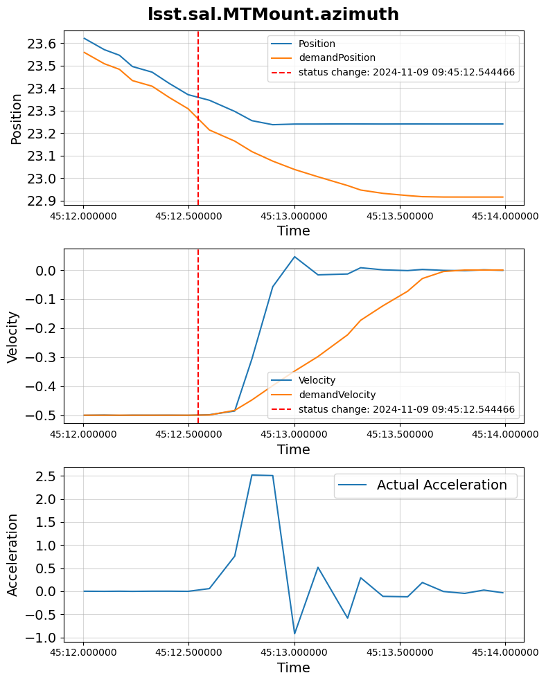

```python
plot_az(df_az, event1)
```

#### Stopping distance = 0.11 deg

## Case 2-6. ComCam onsky: 5% speed El Brake Test

- time_start = "2024-11-09T10:20:45"
- time_ends = "2024-11-09T10:21:10"
- Event happened at: 2024-11-09T10:20:49.569646

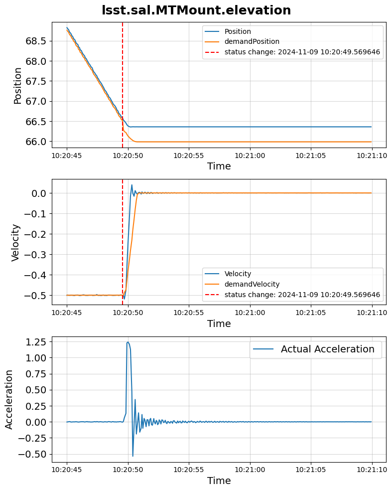

```python
##################################################
time_start = "2024-11-09T10:20:45"
time_ends = "2024-11-09T10:21:10"
##################################################
start, end = format_time(time_start, time_ends)
df_el = call_el_data_range(start, end)
##################################################
plot_el(df_el, event2)
##################################################
```

#### Stopping distance = 0.22 deg

## Case 2-7. ComCam onsky: 10% speed Az Brake Test

- time_start = "2024-11-21T10:41:25"
- time_ends = "2024-11-21T10:41:35"
- Event happened at: 2024-11-21T10:41:28.040349

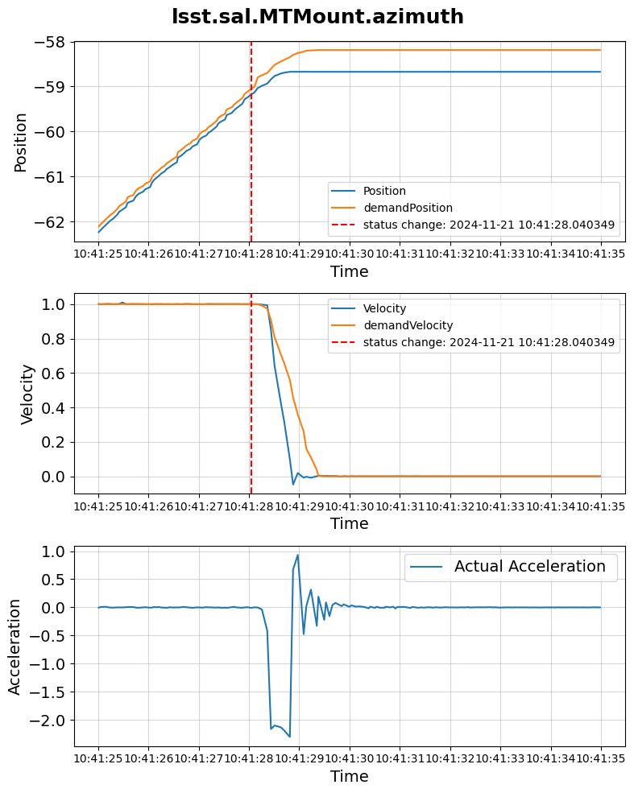

```python
##################################################
time_start = "2024-11-21T10:41:25"
time_ends = "2024-11-21T10:41:35"
##################################################
start, end = format_time(time_start, time_ends)
df_az = call_az_data_range(start, end)
##################################################
plot_az(df_az, event1)
```

## Case 2-8. ComCam onsky: 10% speed El Brake Test

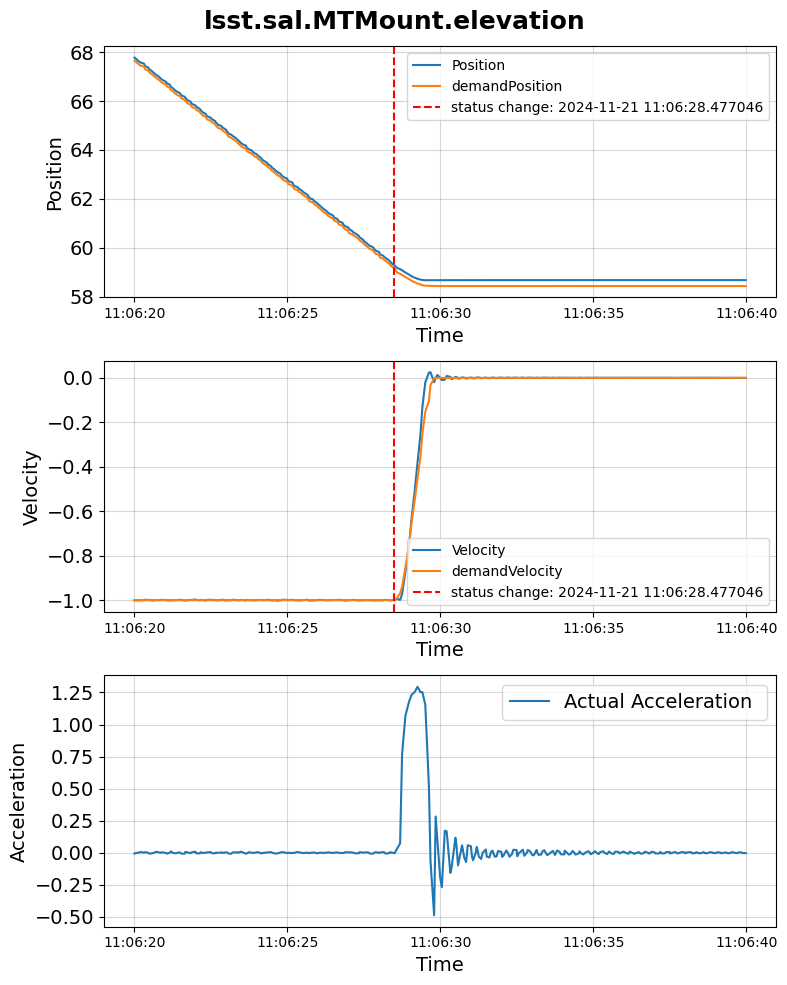

```python
##################################################
time_start = "2024-11-21T11:06:20"
time_ends = "2024-11-21T11:06:40"
##################################################
start, end = format_time(time_start, time_ends)
df_el = call_el_data_range(start, end)
##################################################
plot_el(df_el, event2)
##################################################
```

#### Stopping distance = 0.60 deg

## Case 2-9. ComCam onsky: 20% speed Az Brake Test

- time_start = "2024-11-29T20:04:25"
- time_ends = "2024-11-29T20:04:28"
- Event happened at: 2024-11-29T20:04:26.418824

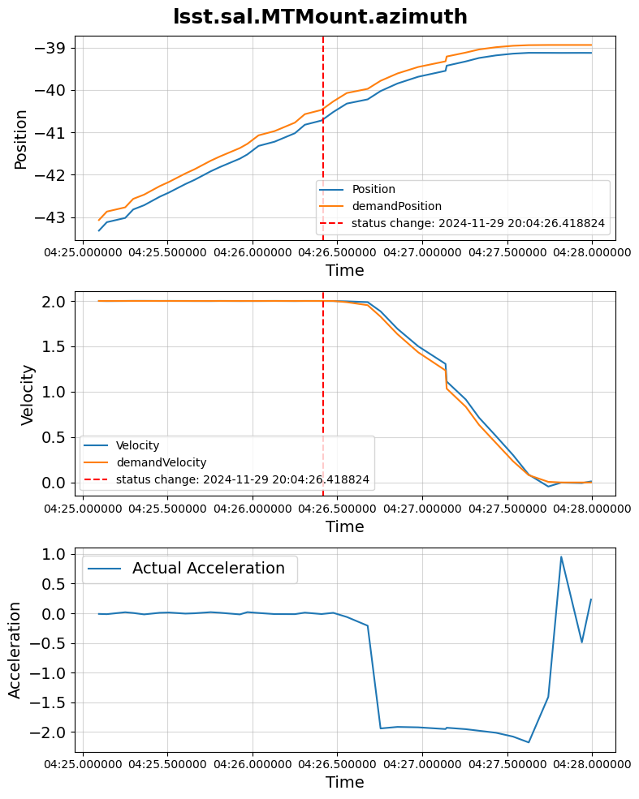

```python
plot_az(df_az, event1)
```

#### Stopping distance = -1.6 deg

## Case 2-10. ComCam onsky: 20% speed El Brake Test

- time_start = "2024-11-29T20:09:09"
- time_ends = "2024-11-29T20:09:13"
- Event happened at: 2024-11-29T20:09:09.582050

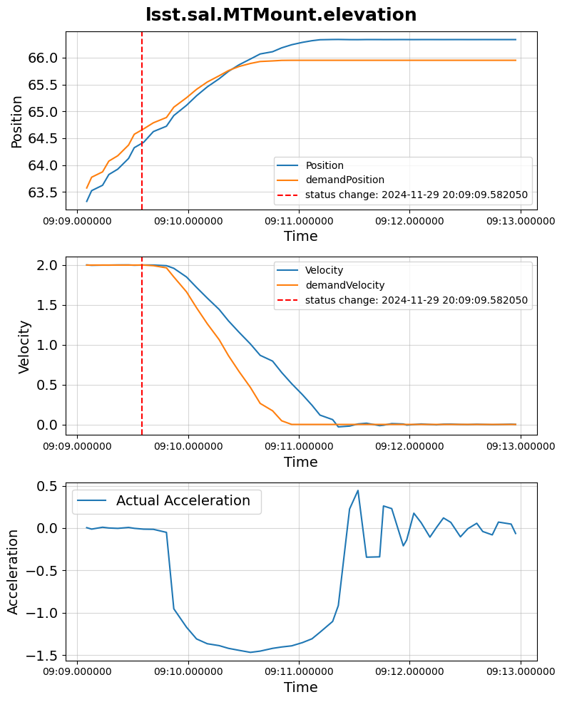

```python
##################################################
time_start = "2024-11-29T20:09:09"
time_ends = "2024-11-29T20:09:13"
##################################################
start, end = format_time(time_start, time_ends)
df_el = call_el_data_range(start, end)
##################################################
plot_el(df_el, event2)
##################################################
```

#### Stopping distance = -1.91 deg

## Case 2-11. ComCam onsky: 40% speed Az Brake Test

- time_start = "2024-12-08T09:06:11"
- time_ends = "2024-12-08T09:06:15"
- Event happened at: 2024-12-08T09:06:11.372613

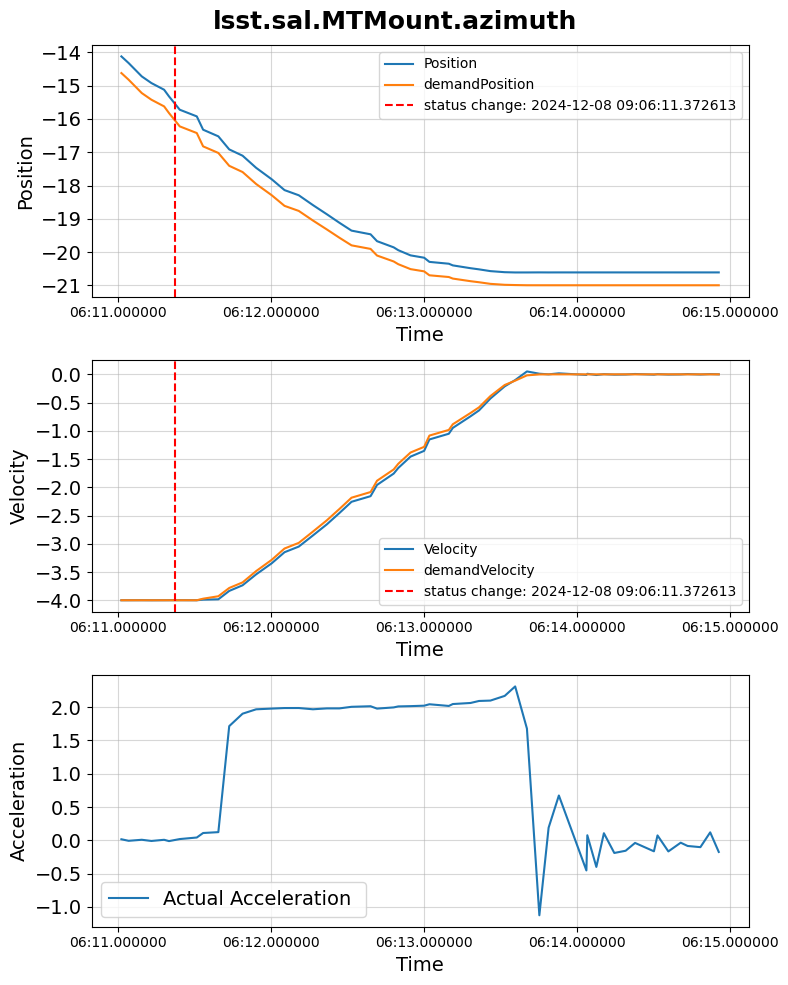

```python
plot_az(df_az, event1)
```

#### Stopping distance = 4.88 deg

## Case 2-12. ComCam onsky: 40% speed El Brake Test

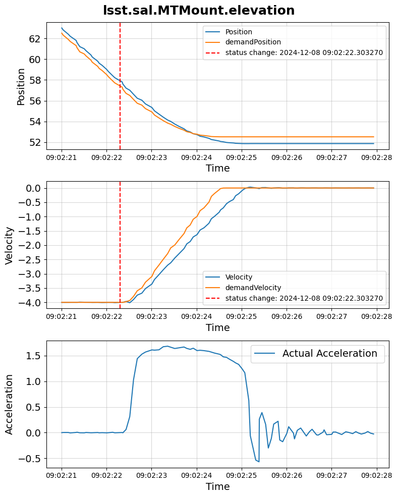

```python
##################################################
time_start = "2024-12-08T09:02:21"
time_ends = "2024-12-08T09:02:28"
##################################################
start, end = format_time(time_start, time_ends)
df_el = call_el_data_range(start, end)
##################################################
plot_el(df_el, event2)
##################################################
```

#### Stopping distance = 5.95 deg